# Project 1 phase2

Keerthana KVSK & Asmitha Bonaventure

Data Mining - Advances

In the classification of the heart disease data set a high dimensional data set is used in the pre processing stage of data mining process. This raw dataset consist of redundant and inconsistent data thereby increasing the search space and storage of the data. To achieve the classification accuracy we need to remove the redundant and the irrelevant data present.

Clinical diagnosis is done mostly by doctor’s expertise and experience. But still cases are reported of wrong diagnosis and treatment.

```r
library(e1071)
library(caret)
library(magrittr)
library(plyr)
library(dplyr)
```

```r
library(corrplot)
library(randomForest)
library(pROC)
library(Epi)
library(nnet)
library(party)
heart.data <- read.csv("https://archive.ics.uci.edu/ml/machine-learning-databases/heart-disease/processed.cleveland.data",header=FALSE,sep=",",na.strings = '?')
```

```r
names(heart.data) <- c( "Age", "Gender", "ChestPain", "RestBP", "Chol","FBS", "RestECG","MaxHR","ExAng", "OldPeak","Slope", "ca", "thal", "HeartDisease")

#Check the dimension of the data
dim(heart.data)
```

```
## [1] 303  14
```

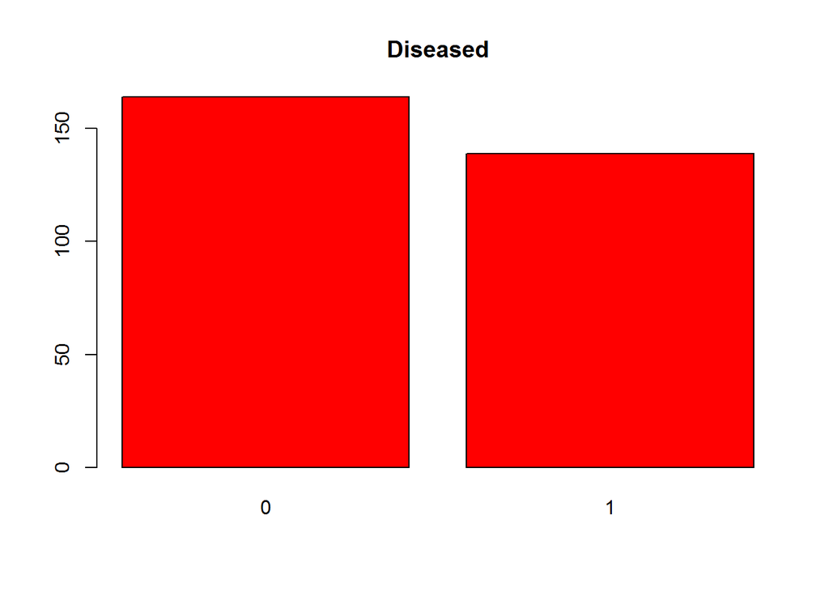

```r
heart.data$HeartDisease[heart.data$HeartDisease > 0] <- 1
barplot(table(heart.data$HeartDisease), main="Diseased", col="Red")
```

```r
heart = heart.data

levels(heart$HeartDisease) = c("No disease","Disease")
levels(heart$Gender) = c("female","male","")
```

Initial Plots:

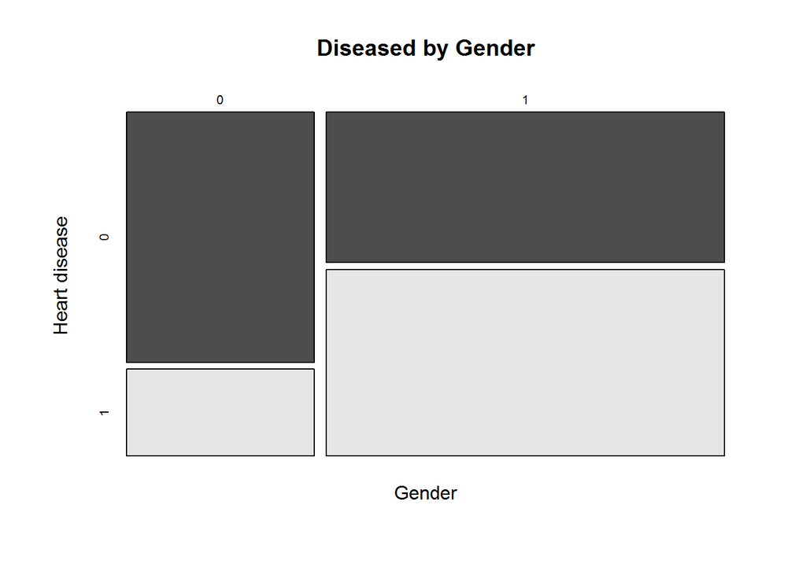

```r
mosaicplot(heart$Gender ~ heart$HeartDisease,
           main="Diseased by Gender", shade=FALSE,color=TRUE,
           xlab="Gender", ylab="Heart disease")
```

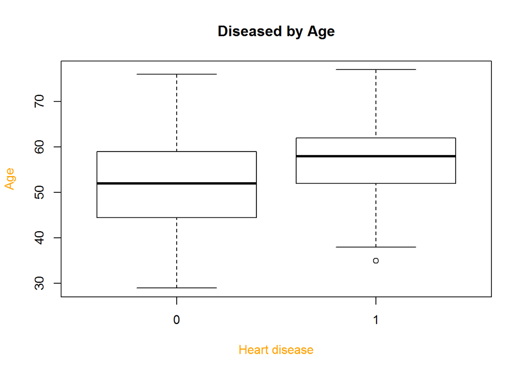

```r
boxplot(heart$Age ~ heart$HeartDisease,
        main="Diseased by Age",
         ylab="Age",xlab="Heart disease",col.lab="Orange")
```

An histogram showing the count of the patients against the Maximum Heart Rate achieved.

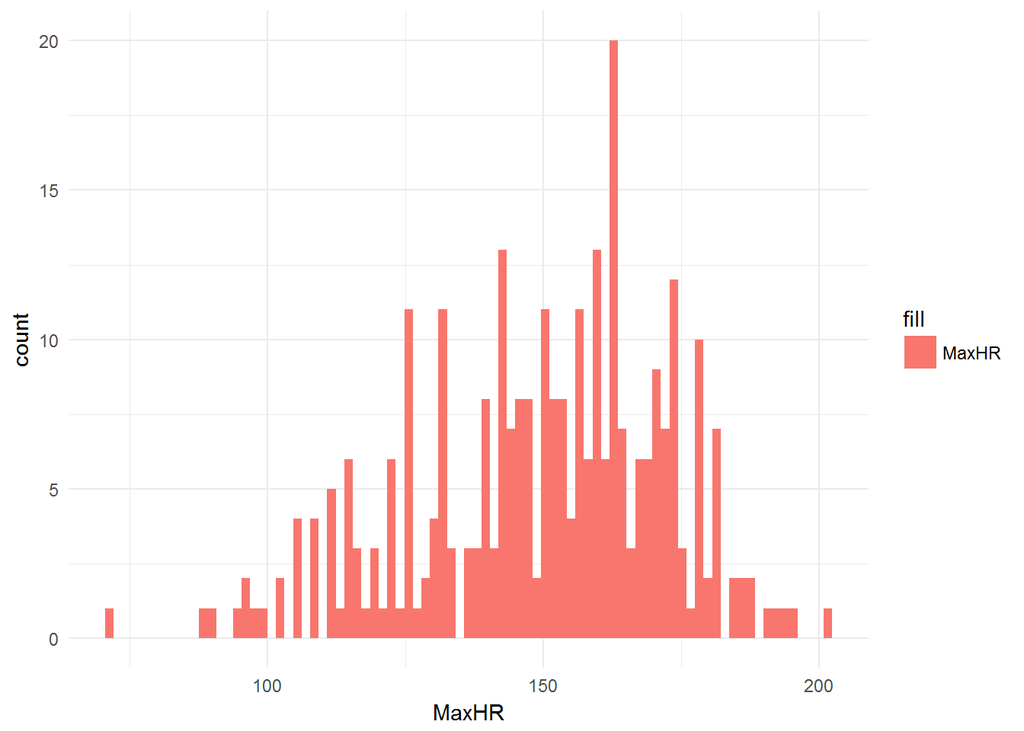

```r
library(ggplot2)
ggplot(heart, aes(MaxHR, fill="MaxHR")) + geom_histogram(position="identity", binwidth=1.55) +theme_minimal()
```

```r
Plot1 <- ggplot(heart.data, aes(Age)) + geom_histogram(binwidth = 1.5, color="white", aes(fill=..count..)) +facet_grid(Gender ~ .) + labs(title = "Heart")
```

```r
heart.data$Age = as.numeric(heart.data$Age)
heart.data$Gender=as.factor(heart.data$Gender)
heart.data$ChestPain=as.factor(heart.data$ChestPain)
heart.data$RestBP=as.numeric(heart.data$RestBP)
heart.data$Chol=as.numeric(heart.data$Chol)
heart.data$FBS=as.factor(heart.data$FBS)
heart.data$RestECG=as.factor(heart.data$RestECG)
heart.data$MaxHR=as.numeric(heart.data$MaxHR)
heart.data$ExAng=as.factor(heart.data$ExAng)
heart.data$OldPeak=as.numeric(heart.data$OldPeak)
heart.data$Slope=as.factor(heart.data$Slope)
heart.data$ca=as.factor(heart.data$ca)
heart.data$thal=as.factor(heart.data$thal)
heart.data$HeartDisease=as.factor(heart.data$HeartDisease)

sum(!complete.cases(heart.data))
```

```
## [1] 6
```

```r
#Removing rows with NaN
heart.data <- heart.data[complete.cases(heart.data),]

categories = cut(heart.data$Age, c(0,20,40,60,Inf))
heart.data$Agegrp = as.numeric(categories)
heart.data$Agegrp = factor(heart.data$Agegrp)


#Removing near zero variance variables
library(caret)
library(magrittr)
library(dplyr)
nzv <- nearZeroVar(heart.data)
names(data)[nzv]
```

```r
#Normalisation
preProcValues <- preProcess(heart.data, method = c("range"))
dataNorm <- predict(preProcValues, heart.data)
#Removing highly correlated variables
d.num <- dataNorm %>% select(which(sapply(dataNorm, is.numeric)))
too_high <- findCorrelation(cor(d.num), cutoff = 0.725, verbose = FALSE)
names(d.num)[too_high]
```

```
## character(0)
```

```r
data = dataNorm[,-c(too_high)]


size <- floor(0.05 * nrow(heart.data))
indxSample <- sample(seq_len(nrow(heart.data)), size = size)
sample <- heart.data[indxSample, ]
length(levels(sample$HeartDisease))
```

```
## [1] 2
```

```r
#SBF
filterCtrl <- sbfControl(functions = rfSBF, method = "repeatedcv", verbose = FALSE, repeats = 5)
rfWithFilter <- sbf(form = HeartDisease ~ ., data = sample, sbfControl = filterCtrl, allowParallel = TRUE, variables=TRUE)
rfWithFilter
```

```
##
## Selection By Filter
##
## Outer resampling method: Cross-Validated (10 fold, repeated 5 times)
##
## Resampling performance:
##
##  Accuracy  Kappa AccuracySD KappaSD
##    0.5114 0.1842     0.4244  0.5626
##
## Using the training set, 3 variables were selected:
##    Age, ChestPain4, Slope2.
##
## During resampling, the top 5 selected variables (out of a possible 11):
##    Slope2 (100%), ca1 (45.5%), ChestPain3 (45.5%), ChestPain4 (31.8%), Age (29.5%)
##
## On average, 3.3 variables were selected (min = 1, max = 6)
```

```r
selections <- rfWithFilter$variables$selectedVars
selections <- append(selections, "HeartDisease")
```

```r
selections
```

```
## [1] "ChestPain3"   "Slope2"       "ca1"          "HeartDisease"
```

```r
data<-heart.data
subdata <- data[c("Age","ExAng","RestECG","thal","MaxHR","HeartDisease")]
head(subdata)
```

```
##   Age ExAng RestECG thal MaxHR HeartDisease
## 1  63     0       2    6   150            0
## 2  67     1       2    3   108            1
## 3  67     1       2    7   129            1
## 4  37     0       0    3   187            0
## 5  41     0       2    3   172            0
## 6  56     0       0    3   178            0
```

```r
summary(subdata)
```

```
##       Age        ExAng   RestECG thal        MaxHR       HeartDisease
##  Min.   :29.00   0:200   0:147   3:164   Min.   : 71.0   0:160
##  1st Qu.:48.00   1: 97   1:  4   6: 18   1st Qu.:133.0   1:137
##  Median :56.00           2:146   7:115   Median :153.0
##  Mean   :54.54                           Mean   :149.6
##  3rd Qu.:61.00                           3rd Qu.:166.0
##  Max.   :77.00                           Max.   :202.0
```

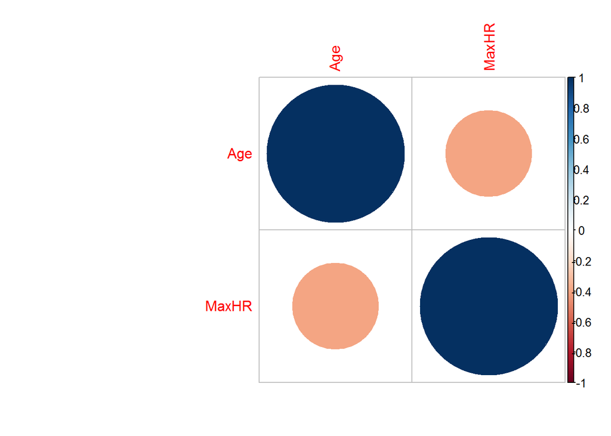

```r
sub.num <- subdata %>% select(which(sapply(subdata, is.numeric)))
corrplot(cor(sub.num), method="circle")
```

Data splitting

```r
set.seed(1313)
size <- floor(0.75 * nrow(subdata))
indxTrain <- sample(seq_len(nrow(subdata)), size = size)

dataTrain <- subdata[indxTrain, ]
dataTest <- subdata[-indxTrain, ]
```

# Classifiers

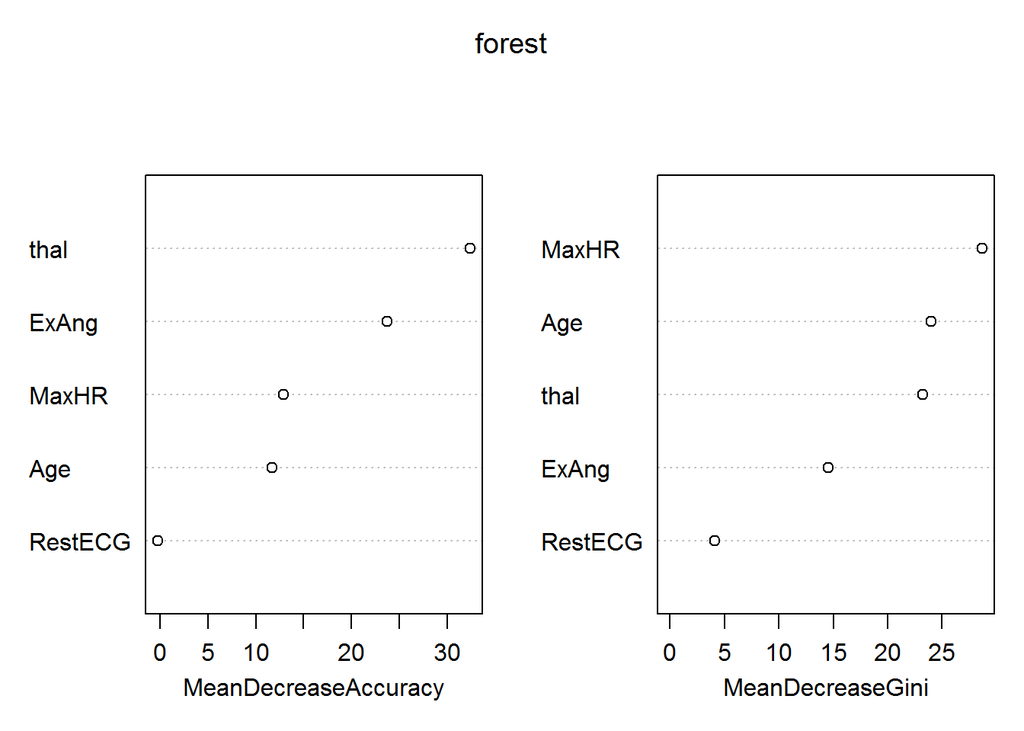

```r
forest <- randomForest(HeartDisease ~ ., data = dataTrain, importance = TRUE, na.action = na.omit)
varImpPlot(forest)
```

```r
importance(forest)
```

```
##                 0          1 MeanDecreaseAccuracy MeanDecreaseGini
## Age      8.958716  7.1706055            11.733263        23.957656
## ExAng   16.318137 17.8225603            23.759598        14.548409
## RestECG -1.223364  0.9126259            -0.198029         4.100263
## thal    27.177790 22.9865267            32.374944        23.222252
## MaxHR    9.033277  9.7362341            12.887571        28.666544
```

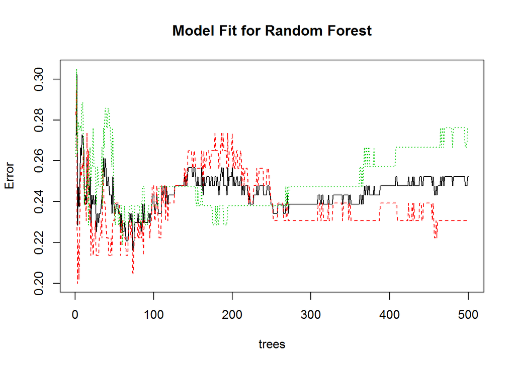

```r
predForest = predict(forest, dataTest, type="class")
plot(forest, main="Model Fit for Random Forest")
```

```r
forestTab <- table(true = dataTest$HeartDisease, predicted = predForest)
rfAcc <- sum(diag(forestTab)) / sum(forestTab)
rfAcc
```

```
## [1] 0.6933333
```